# Risk Factor Analysis

## Outcome Variable

**Outcome Variable:** dead

## Predictor Variables

**Intervention Variable:** ever_sstunted06

**Adjustment Set:**

- sex
- arm
- brthmon
- vagbrth
- impfloor
- hhwealth_quart
- W_mage
- W_mhtcm
- W_mwtkg
- W_mbmi
- W_meducyrs
- W_feducyrs
- W_nrooms
- W_nchldlt5
- W_parity
- impsan
- safeh20
- delta_vagbrth
- delta_impfloor
- delta_hhwealth_quart
- delta_W_mage
- delta_W_mhtcm
- delta_W_mwtkg
- delta_W_mbmi
- delta_W_meducyrs
- delta_W_feducyrs
- delta_W_nrooms
- delta_W_nchldlt5
- delta_W_parity
- delta_impsan
- delta_safeh20

## Stratifying Variables

The analysis was stratified on these variable(s):

- studyid
- country

## Data Summary

| studyid | country | ever_sstunted06 | dead | n_cell | n | outcome_variable |
| --- | --- | --- | --- | --- | --- | --- |
| Burkina Faso Zn | BURKINA FASO | 0 | 0 | 325 | 338 | dead |
| Burkina Faso Zn | BURKINA FASO | 0 | 1 | 2 | 338 | dead |
| Burkina Faso Zn | BURKINA FASO | 1 | 0 | 11 | 338 | dead |
| Burkina Faso Zn | BURKINA FASO | 1 | 1 | 0 | 338 | dead |
| EE | PAKISTAN | 0 | 0 | 213 | 379 | dead |
| EE | PAKISTAN | 0 | 1 | 3 | 379 | dead |
| EE | PAKISTAN | 1 | 0 | 162 | 379 | dead |
| EE | PAKISTAN | 1 | 1 | 1 | 379 | dead |
| GMS-Nepal | NEPAL | 0 | 0 | 634 | 698 | dead |
| GMS-Nepal | NEPAL | 0 | 1 | 4 | 698 | dead |
| GMS-Nepal | NEPAL | 1 | 0 | 56 | 698 | dead |
| GMS-Nepal | NEPAL | 1 | 1 | 4 | 698 | dead |
| iLiNS-DOSE | MALAWI | 0 | 0 | 1588 | 1813 | dead |
| iLiNS-DOSE | MALAWI | 0 | 1 | 101 | 1813 | dead |
| iLiNS-DOSE | MALAWI | 1 | 0 | 111 | 1813 | dead |
| iLiNS-DOSE | MALAWI | 1 | 1 | 13 | 1813 | dead |
| iLiNS-DYAD-M | MALAWI | 0 | 0 | 1066 | 1191 | dead |
| iLiNS-DYAD-M | MALAWI | 0 | 1 | 34 | 1191 | dead |
| iLiNS-DYAD-M | MALAWI | 1 | 0 | 86 | 1191 | dead |
| iLiNS-DYAD-M | MALAWI | 1 | 1 | 5 | 1191 | dead |
| JiVitA-3 | BANGLADESH | 0 | 0 | 22511 | 27197 | dead |
| JiVitA-3 | BANGLADESH | 0 | 1 | 435 | 27197 | dead |
| JiVitA-3 | BANGLADESH | 1 | 0 | 3885 | 27197 | dead |
| JiVitA-3 | BANGLADESH | 1 | 1 | 366 | 27197 | dead |
| JiVitA-4 | BANGLADESH | 0 | 0 | 4639 | 5270 | dead |
| JiVitA-4 | BANGLADESH | 0 | 1 | 31 | 5270 | dead |
| JiVitA-4 | BANGLADESH | 1 | 0 | 584 | 5270 | dead |
| JiVitA-4 | BANGLADESH | 1 | 1 | 16 | 5270 | dead |
| Keneba | GAMBIA | 0 | 0 | 2142 | 2479 | dead |
| Keneba | GAMBIA | 0 | 1 | 43 | 2479 | dead |
| Keneba | GAMBIA | 1 | 0 | 278 | 2479 | dead |
| Keneba | GAMBIA | 1 | 1 | 16 | 2479 | dead |
| MAL-ED | BANGLADESH | 0 | 0 | 240 | 265 | dead |
| MAL-ED | BANGLADESH | 0 | 1 | 2 | 265 | dead |
| MAL-ED | BANGLADESH | 1 | 0 | 22 | 265 | dead |
| MAL-ED | BANGLADESH | 1 | 1 | 1 | 265 | dead |
| MAL-ED | INDIA | 0 | 0 | 228 | 251 | dead |
| MAL-ED | INDIA | 0 | 1 | 2 | 251 | dead |
| MAL-ED | INDIA | 1 | 0 | 21 | 251 | dead |
| MAL-ED | INDIA | 1 | 1 | 0 | 251 | dead |
| MAL-ED | PERU | 0 | 0 | 260 | 303 | dead |
| MAL-ED | PERU | 0 | 1 | 2 | 303 | dead |
| MAL-ED | PERU | 1 | 0 | 41 | 303 | dead |
| MAL-ED | PERU | 1 | 1 | 0 | 303 | dead |
| MAL-ED | SOUTH AFRICA | 0 | 0 | 283 | 314 | dead |
| MAL-ED | SOUTH AFRICA | 0 | 1 | 0 | 314 | dead |
| MAL-ED | SOUTH AFRICA | 1 | 0 | 30 | 314 | dead |
| MAL-ED | SOUTH AFRICA | 1 | 1 | 1 | 314 | dead |
| MAL-ED | TANZANIA, UNITED REPUBLIC OF | 0 | 0 | 219 | 262 | dead |
| MAL-ED | TANZANIA, UNITED REPUBLIC OF | 0 | 1 | 2 | 262 | dead |
| MAL-ED | TANZANIA, UNITED REPUBLIC OF | 1 | 0 | 40 | 262 | dead |
| MAL-ED | TANZANIA, UNITED REPUBLIC OF | 1 | 1 | 1 | 262 | dead |
| PROVIDE | BANGLADESH | 0 | 0 | 665 | 700 | dead |
| PROVIDE | BANGLADESH | 0 | 1 | 4 | 700 | dead |
| PROVIDE | BANGLADESH | 1 | 0 | 31 | 700 | dead |
| PROVIDE | BANGLADESH | 1 | 1 | 0 | 700 | dead |
| SAS-CompFeed | INDIA | 0 | 0 | 1266 | 1532 | dead |
| SAS-CompFeed | INDIA | 0 | 1 | 29 | 1532 | dead |
| SAS-CompFeed | INDIA | 1 | 0 | 216 | 1532 | dead |
| SAS-CompFeed | INDIA | 1 | 1 | 21 | 1532 | dead |
| SAS-FoodSuppl | INDIA | 0 | 0 | 351 | 418 | dead |
| SAS-FoodSuppl | INDIA | 0 | 1 | 3 | 418 | dead |
| SAS-FoodSuppl | INDIA | 1 | 0 | 61 | 418 | dead |
| SAS-FoodSuppl | INDIA | 1 | 1 | 3 | 418 | dead |
| TanzaniaChild2 | TANZANIA, UNITED REPUBLIC OF | 0 | 0 | 2284 | 2396 | dead |
| TanzaniaChild2 | TANZANIA, UNITED REPUBLIC OF | 0 | 1 | 1 | 2396 | dead |
| TanzaniaChild2 | TANZANIA, UNITED REPUBLIC OF | 1 | 0 | 111 | 2396 | dead |
| TanzaniaChild2 | TANZANIA, UNITED REPUBLIC OF | 1 | 1 | 0 | 2396 | dead |
| VITAMIN-A | INDIA | 0 | 0 | 3274 | 3898 | dead |
| VITAMIN-A | INDIA | 0 | 1 | 50 | 3898 | dead |
| VITAMIN-A | INDIA | 1 | 0 | 547 | 3898 | dead |
| VITAMIN-A | INDIA | 1 | 1 | 27 | 3898 | dead |
| ZVITAMBO | ZIMBABWE | 0 | 0 | 11756 | 14060 | dead |
| ZVITAMBO | ZIMBABWE | 0 | 1 | 871 | 14060 | dead |
| ZVITAMBO | ZIMBABWE | 1 | 0 | 1199 | 14060 | dead |
| ZVITAMBO | ZIMBABWE | 1 | 1 | 234 | 14060 | dead |

The following strata were considered:

- studyid: Burkina Faso Zn, country: BURKINA FASO
- studyid: EE, country: PAKISTAN
- studyid: GMS-Nepal, country: NEPAL
- studyid: iLiNS-DOSE, country: MALAWI
- studyid: iLiNS-DYAD-M, country: MALAWI
- studyid: JiVitA-3, country: BANGLADESH
- studyid: JiVitA-4, country: BANGLADESH
- studyid: Keneba, country: GAMBIA
- studyid: MAL-ED, country: BANGLADESH
- studyid: MAL-ED, country: INDIA
- studyid: MAL-ED, country: PERU
- studyid: MAL-ED, country: SOUTH AFRICA
- studyid: MAL-ED, country: TANZANIA, UNITED REPUBLIC OF
- studyid: PROVIDE, country: BANGLADESH
- studyid: SAS-CompFeed, country: INDIA
- studyid: SAS-FoodSuppl, country: INDIA
- studyid: TanzaniaChild2, country: TANZANIA, UNITED REPUBLIC OF
- studyid: VITAMIN-A, country: INDIA
- studyid: ZVITAMBO, country: ZIMBABWE

### Dropped Strata

Some strata were dropped due to rare outcomes:

- studyid: Burkina Faso Zn, country: BURKINA FASO
- studyid: EE, country: PAKISTAN
- studyid: GMS-Nepal, country: NEPAL
- studyid: MAL-ED, country: BANGLADESH
- studyid: MAL-ED, country: INDIA
- studyid: MAL-ED, country: PERU
- studyid: MAL-ED, country: SOUTH AFRICA
- studyid: MAL-ED, country: TANZANIA, UNITED REPUBLIC OF
- studyid: PROVIDE, country: BANGLADESH
- studyid: SAS-FoodSuppl, country: INDIA
- studyid: TanzaniaChild2, country: TANZANIA, UNITED REPUBLIC OF

## Methods Detail

We’re interested in the causal parameters $E[Y_a]$ for all values of $a \in \mathcal{A}$. These parameters represent the mean outcome if, possibly contrary to fact, we intervened to set all units to have $A=a$. Under the randomization and positivity assumptions, these are identified by the statistical parameters $\psi_a=E_W[E_{Y|A,W}(Y|A=a,W)]$. In addition, we’re interested in the mean of $Y$, $E[Y]$ under no intervention (the observed mean). We will estimate these parameters by using SuperLearner to fit the relevant likelihood factors – $E_{Y|A,W}(Y|A=a,W)$ and $p(A=a|W)$, and then updating our likelihood fit using a joint TMLE.

For unadjusted analyses ($W=\{\}$), initial likelihoods were estimated using Lrnr_glm to estimate the simple $E(Y|A)$ and Lrnr_mean to estimate $p(A)$. For adjusted analyses, a small library containing Lrnr_glmnet, Lrnr_xgboost, and Lrnr_mean was used.

Having estimated these parameters, we will then use the delta method to estimate relative risks and attributable risks relative to a prespecified baseline level of $A$.

[output not shown]

# Results Detail

## Results Plots

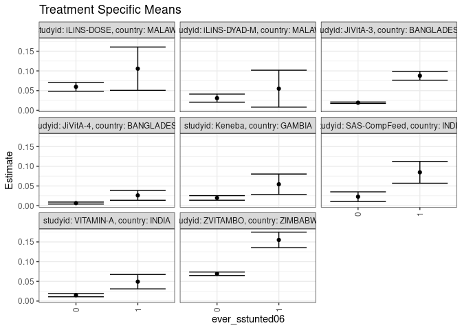

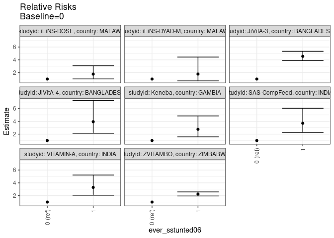

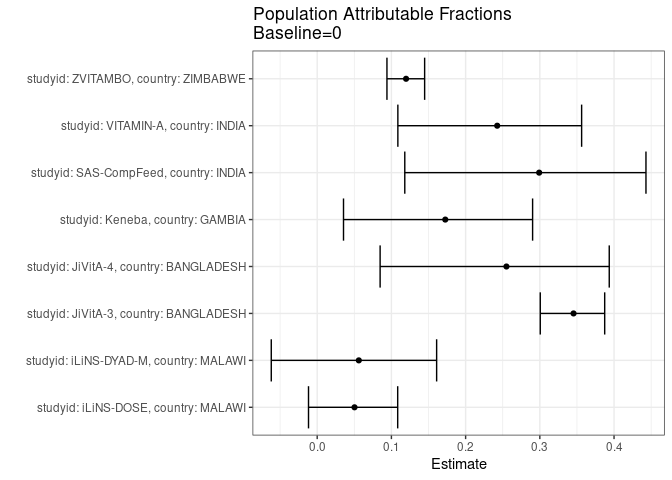

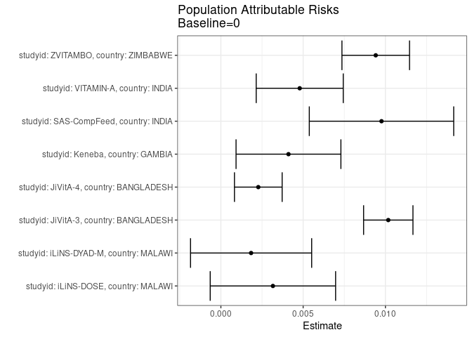

## Results Table

### Parameter: TSM

| studyid | country | intervention_level | baseline_level | estimate | ci_lower | ci_upper |
| --- | --- | --- | --- | --- | --- | --- |
| iLiNS-DOSE | MALAWI | 0 | NA | 0.0597173 | 0.0484082 | 0.0710263 |
| iLiNS-DOSE | MALAWI | 1 | NA | 0.1056725 | 0.0507463 | 0.1605986 |
| iLiNS-DYAD-M | MALAWI | 0 | NA | 0.0309091 | 0.0206771 | 0.0411411 |
| iLiNS-DYAD-M | MALAWI | 1 | NA | 0.0549451 | 0.0081066 | 0.1017835 |
| JiVitA-3 | BANGLADESH | 0 | NA | 0.0192782 | 0.0174543 | 0.0211020 |
| JiVitA-3 | BANGLADESH | 1 | NA | 0.0876847 | 0.0764644 | 0.0989049 |
| JiVitA-4 | BANGLADESH | 0 | NA | 0.0066442 | 0.0040617 | 0.0092268 |
| JiVitA-4 | BANGLADESH | 1 | NA | 0.0261682 | 0.0137254 | 0.0386110 |
| Keneba | GAMBIA | 0 | NA | 0.0196917 | 0.0138622 | 0.0255212 |
| Keneba | GAMBIA | 1 | NA | 0.0543649 | 0.0284139 | 0.0803159 |
| SAS-CompFeed | INDIA | 0 | NA | 0.0228750 | 0.0106146 | 0.0351354 |
| SAS-CompFeed | INDIA | 1 | NA | 0.0847069 | 0.0570281 | 0.1123856 |
| VITAMIN-A | INDIA | 0 | NA | 0.0149622 | 0.0108323 | 0.0190921 |
| VITAMIN-A | INDIA | 1 | NA | 0.0491906 | 0.0309113 | 0.0674699 |
| ZVITAMBO | ZIMBABWE | 0 | NA | 0.0691803 | 0.0647461 | 0.0736145 |
| ZVITAMBO | ZIMBABWE | 1 | NA | 0.1550909 | 0.1352669 | 0.1749149 |

### Parameter: E(Y)

| studyid | country | intervention_level | baseline_level | estimate | ci_lower | ci_upper |
| --- | --- | --- | --- | --- | --- | --- |
| iLiNS-DOSE | MALAWI | NA | NA | 0.0628792 | 0.0517023 | 0.0740561 |
| iLiNS-DYAD-M | MALAWI | NA | NA | 0.0327456 | 0.0226340 | 0.0428572 |
| JiVitA-3 | BANGLADESH | NA | NA | 0.0294518 | 0.0273600 | 0.0315436 |
| JiVitA-4 | BANGLADESH | NA | NA | 0.0089184 | 0.0062077 | 0.0116291 |
| Keneba | GAMBIA | NA | NA | 0.0237999 | 0.0177985 | 0.0298013 |
| SAS-CompFeed | INDIA | NA | NA | 0.0326371 | 0.0205116 | 0.0447625 |
| VITAMIN-A | INDIA | NA | NA | 0.0197537 | 0.0153848 | 0.0241226 |
| ZVITAMBO | ZIMBABWE | NA | NA | 0.0785917 | 0.0741435 | 0.0830400 |

### Parameter: RR

| studyid | country | intervention_level | baseline_level | estimate | ci_lower | ci_upper |
| --- | --- | --- | --- | --- | --- | --- |
| iLiNS-DOSE | MALAWI | 0 | 0 | 1.000000 | 1.000000 | 1.000000 |
| iLiNS-DOSE | MALAWI | 1 | 0 | 1.769546 | 1.017671 | 3.076922 |
| iLiNS-DYAD-M | MALAWI | 0 | 0 | 1.000000 | 1.000000 | 1.000000 |
| iLiNS-DYAD-M | MALAWI | 1 | 0 | 1.777634 | 0.712343 | 4.436041 |
| JiVitA-3 | BANGLADESH | 0 | 0 | 1.000000 | 1.000000 | 1.000000 |
| JiVitA-3 | BANGLADESH | 1 | 0 | 4.548393 | 3.875405 | 5.338250 |
| JiVitA-4 | BANGLADESH | 0 | 0 | 1.000000 | 1.000000 | 1.000000 |
| JiVitA-4 | BANGLADESH | 1 | 0 | 3.938476 | 2.136813 | 7.259219 |
| Keneba | GAMBIA | 0 | 0 | 1.000000 | 1.000000 | 1.000000 |
| Keneba | GAMBIA | 1 | 0 | 2.760796 | 1.574203 | 4.841812 |
| SAS-CompFeed | INDIA | 0 | 0 | 1.000000 | 1.000000 | 1.000000 |
| SAS-CompFeed | INDIA | 1 | 0 | 3.703031 | 2.270391 | 6.039681 |
| VITAMIN-A | INDIA | 0 | 0 | 1.000000 | 1.000000 | 1.000000 |
| VITAMIN-A | INDIA | 1 | 0 | 3.287667 | 2.069753 | 5.222242 |
| ZVITAMBO | ZIMBABWE | 0 | 0 | 1.000000 | 1.000000 | 1.000000 |
| ZVITAMBO | ZIMBABWE | 1 | 0 | 2.241836 | 1.944239 | 2.584986 |

### Parameter: PAR

| studyid | country | intervention_level | baseline_level | estimate | ci_lower | ci_upper |
| --- | --- | --- | --- | --- | --- | --- |
| iLiNS-DOSE | MALAWI | 0 | NA | 0.0031619 | -0.0006486 | 0.0069724 |
| iLiNS-DYAD-M | MALAWI | 0 | NA | 0.0018365 | -0.0018446 | 0.0055176 |
| JiVitA-3 | BANGLADESH | 0 | NA | 0.0101736 | 0.0086738 | 0.0116734 |
| JiVitA-4 | BANGLADESH | 0 | NA | 0.0022742 | 0.0008251 | 0.0037232 |
| Keneba | GAMBIA | 0 | NA | 0.0041082 | 0.0009219 | 0.0072945 |
| SAS-CompFeed | INDIA | 0 | NA | 0.0097621 | 0.0053737 | 0.0141505 |
| VITAMIN-A | INDIA | 0 | NA | 0.0047916 | 0.0021466 | 0.0074365 |
| ZVITAMBO | ZIMBABWE | 0 | NA | 0.0094115 | 0.0073578 | 0.0114651 |

### Parameter: PAF

| studyid | country | intervention_level | baseline_level | estimate | ci_lower | ci_upper |
| --- | --- | --- | --- | --- | --- | --- |
| iLiNS-DOSE | MALAWI | 0 | NA | 0.0502858 | -0.0116983 | 0.1084723 |
| iLiNS-DYAD-M | MALAWI | 0 | NA | 0.0560839 | -0.0618845 | 0.1609468 |
| JiVitA-3 | BANGLADESH | 0 | NA | 0.3454328 | 0.3005873 | 0.3874029 |
| JiVitA-4 | BANGLADESH | 0 | NA | 0.2549960 | 0.0847878 | 0.3935494 |
| Keneba | GAMBIA | 0 | NA | 0.1726133 | 0.0354597 | 0.2902642 |
| SAS-CompFeed | INDIA | 0 | NA | 0.2991098 | 0.1180246 | 0.4430151 |
| VITAMIN-A | INDIA | 0 | NA | 0.2425646 | 0.1086994 | 0.3563245 |
| ZVITAMBO | ZIMBABWE | 0 | NA | 0.1197511 | 0.0939927 | 0.1447772 |